# RNA-seq analysis in R

Gene Set Testing for RNA-seq - Solutions

Last modified: 23 Mar 2021

## Exercise 1

> 1. Use `pathview` to export a figure for “mmu04659”, but this time only use genes that are statistically significant at FDR < 0.01

```r
logFC <- shrink.d11 %>%
  drop_na(FDR, Entrez) %>%
  filter(FDR < 0.01) %>%
  dplyr::select(Entrez, logFC) %>%
  deframe()

pathview(gene.data = logFC,
         pathway.id = "mmu04659",
         species = "mmu",
         limit = list(gene=5, cpd=1))
```

```
## Info: Working in directory /ssd/personal/baller01/20200615_SawleA_ME_NewData/Bulk_RNAseq_Course_2021/Markdowns
```

```
## Info: Writing image file mmu04659.pathview.png
```

mmu04659.pathview.png:

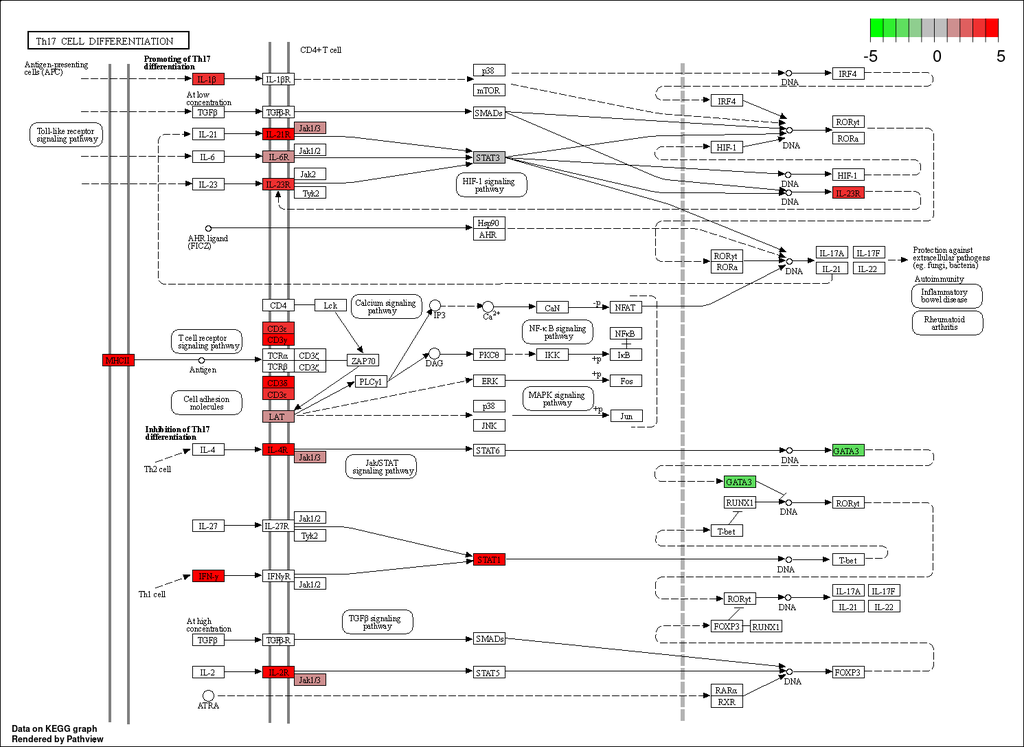

mmu04659 - Th17 cell differentiation

## Exercise 2 - GO term enrichment analysis

> `clusterProfiler` can also perform over-representation analysis on GO terms. using the commmand `enrichGO`. Look at the help page for the command `enrichGO` (`?enrichGO`) and have a look at the instructions in the [clusterProfiler book](http://yulab-smu.top/clusterProfiler-book/chapter5.html#go-over-representation-test).
> 1. Run the over-representation analysis for GO terms
>    - Use genes that have an adjusted p-value (FDR) of less than 0.01 and an absolute fold change greater than 2.
>    - For this analysis you can use Ensembl IDs rather then Entrez
>    - You’ll need to provide the background (`universe`) genes, this should be all the genes in our analysis.
>    - The mouse database package is called `org.Mm.eg.db`. You’ll need to load it using `library` before running the analysis.
>    - As we are using Ensembl IDs, you’ll need to set the `keyType` parameter in the `enrichGO` command to indicate this.
>    - Only test terms in the “Biological Pathway” ontology
> 2. Use the `dotplot` function to visualise the results.

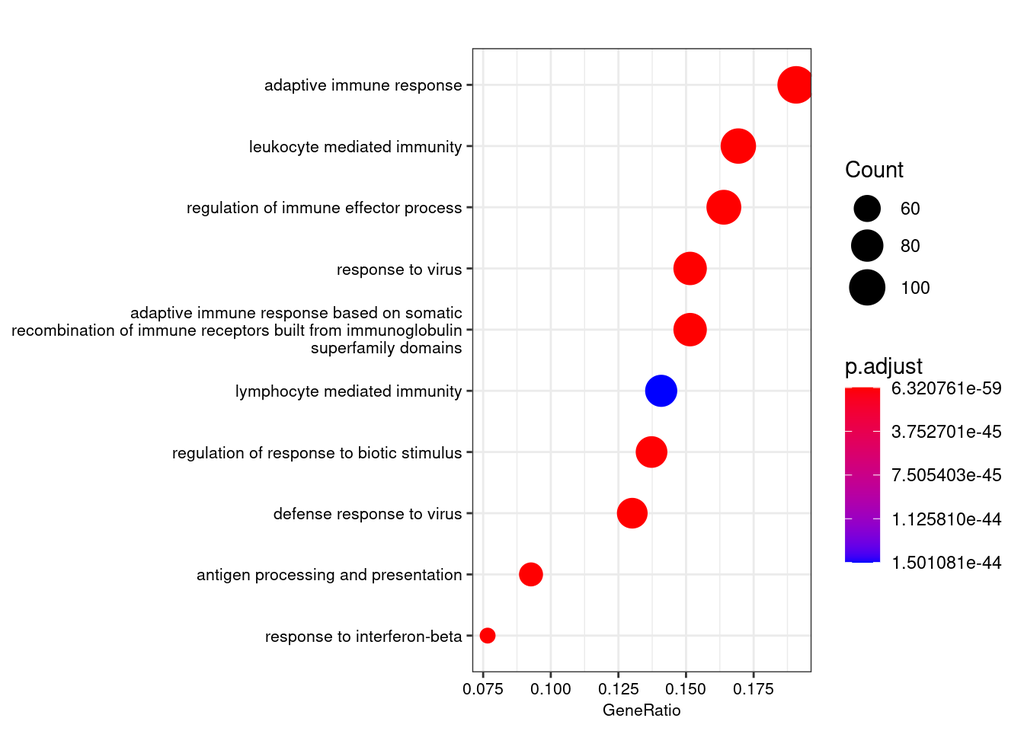

```r
suppressMessages(library(org.Mm.eg.db))

sigGenes <-  shrink.d11 %>%
    drop_na(FDR) %>%
    filter(FDR < 0.01 & abs(logFC) > 1) %>%
    pull(GeneID)

universe <- shrink.d11$GeneID

ego <- enrichGO(gene          = sigGenes,
                universe      = universe,
                OrgDb         = org.Mm.eg.db,
                keyType       = "ENSEMBL",
                ont           = "BP",
                pvalueCutoff  = 0.01,
                readable      = TRUE)

dotplot(ego,
        font.size = 8,
        label_format=20
        )
```

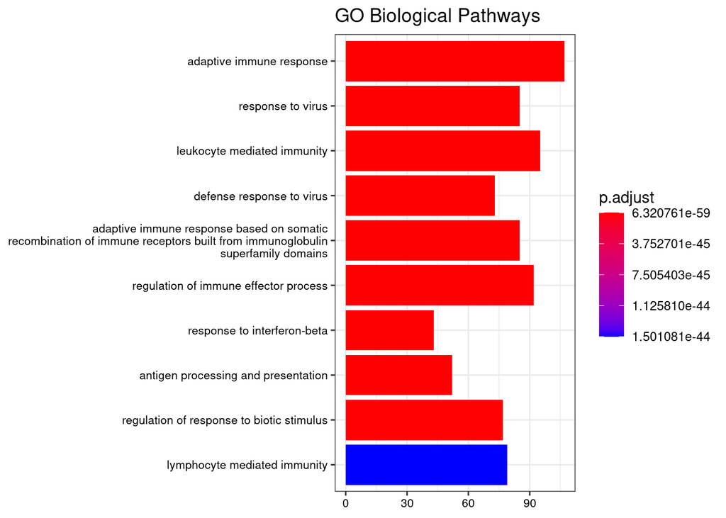

```r
barplot(ego,
        drop = TRUE,
        showCategory = 10,
        label_format = 20,
        title = "GO Biological Pathways",
        font.size = 8)
```

## Exercise 3

> Another common way to rank the genes is to order by pvalue, but also, sorting so that upregulated genes are at the start and downregulated at the end - you can do this combining the sign of the fold change and the pvalue.
> 1. Rank the genes by statisical significance - you will need to create a new ranking value using `-log10({p value}) * sign({Fold Change})`
> 2. Run `fgsea` using the new ranked genes and the H pathways
> 3. Conduct the same analysis for the d33 vs control contrast.

### Exercise 3 - d11 new rank

```r
# 1. Rank the genes by statistical significance - you will need to create
# a new ranking value using `-log10({p value}) * sign({Fold Change})`

# obtain the H(allmarks) catalog for mouse:
m_H_t2g <- msigdbr(species = "Mus musculus", category = "H") %>%
  dplyr::select(gs_name, entrez_gene, gene_symbol)

# rank genes
rankedGenes.e1 <- shrink.d11 %>%
  drop_na(Entrez, pvalue, logFC) %>%
  # rank genes by strength of significance,
  # keeping the direction of the fold change
  mutate(rank = -log10(pvalue) * sign(logFC)) %>%
  # sort genes by decreasing rank.
  arrange(-rank) %>%
  # keep ranks and Entrez IDs
  pull(rank,Entrez)

# conduct analysis:
gseaRes.e1 <- GSEA(rankedGenes.e1,
                TERM2GENE = m_H_t2g[,c("gs_name", "entrez_gene")],
                #pvalueCutoff = 0.05,
                pvalueCutoff = 1.00, # to retrieve whole output
                minGSSize = 15,
                maxGSSize = 500)
```

```
## preparing geneSet collections...
```

```
## GSEA analysis...
```

```
## leading edge analysis...
```

```
## done...
```

```r
# have function to format in scientific notation
format.e1 <- function(x) (sprintf("%.1e", x))
# format table:
gseaRes.e1 %>%
  # sort in decreasing order of absolute NES
  arrange(desc(abs(NES))) %>%
  # only keep the 10 entries with the lowest p.adjust
  top_n(10, -p.adjust) %>%
  # remove columns 'core_enrichment' and 'Description'
  dplyr::select(-core_enrichment) %>%
  dplyr::select(-Description) %>%
  # convert to data.frame
  data.frame() %>%
  # remove row names
  remove_rownames() %>%
  # format score
  mutate(NES=formatC(NES, digits = 3)) %>%
  mutate(ES=formatC(enrichmentScore, digits = 3)) %>%
  relocate(ES, .before=NES) %>%
  dplyr::select(-enrichmentScore) %>%
  # format p-values
  modify_at(
    c("pvalue", "p.adjust", "qvalues"),
    format.e1
  ) %>%
  # display
  DT::datatable(options = list(dom = 't'))
```

|  | ID | setSize | ES | NES | pvalue | p.adjust | qvalues | rank | leading_edge |
| --- | --- | --- | --- | --- | --- | --- | --- | --- | --- |
| 1 | HALLMARK_INTERFERON_ALPHA_RESPONSE | 92 | 0.948 | 1.98 | 1.0e-10 | 1.7e-09 | 1.2e-09 | 619 | tags=75%, list=4%, signal=73% |
| 2 | HALLMARK_OXIDATIVE_PHOSPHORYLATION | 198 | -0.492 | -1.97 | 3.8e-08 | 4.7e-07 | 3.5e-07 | 4323 | tags=56%, list=25%, signal=42% |
| 3 | HALLMARK_INTERFERON_GAMMA_RESPONSE | 193 | 0.942 | 1.96 | 1.0e-10 | 1.7e-09 | 1.2e-09 | 824 | tags=70%, list=5%, signal=68% |
| 4 | HALLMARK_ALLOGRAFT_REJECTION | 193 | 0.899 | 1.87 | 1.0e-10 | 1.7e-09 | 1.2e-09 | 874 | tags=45%, list=5%, signal=43% |
| 5 | HALLMARK_IL6_JAK_STAT3_SIGNALING | 83 | 0.876 | 1.82 | 1.2e-05 | 7.2e-05 | 5.3e-05 | 1422 | tags=55%, list=8%, signal=51% |
| 6 | HALLMARK_INFLAMMATORY_RESPONSE | 195 | 0.828 | 1.72 | 4.3e-07 | 4.3e-06 | 3.1e-06 | 1106 | tags=38%, list=6%, signal=36% |
| 7 | HALLMARK_COMPLEMENT | 189 | 0.814 | 1.69 | 5.2e-06 | 4.3e-05 | 3.2e-05 | 1294 | tags=32%, list=8%, signal=30% |
| 8 | HALLMARK_TNFA_SIGNALING_VIA_NFKB | 195 | 0.802 | 1.67 | 9.2e-06 | 6.6e-05 | 4.9e-05 | 1621 | tags=43%, list=9%, signal=39% |
| 9 | HALLMARK_APOPTOSIS | 158 | 0.803 | 1.66 | 3.5e-05 | 1.9e-04 | 1.4e-04 | 1545 | tags=32%, list=9%, signal=29% |
| 10 | HALLMARK_IL2_STAT5_SIGNALING | 196 | 0.773 | 1.61 | 3.4e-04 | 1.7e-03 | 1.3e-03 | 1106 | tags=25%, list=6%, signal=24% |

### Exercise 3 - d33

With d33 and H catalog:

```r
# read d33 data in:
shrink.d33 <- readRDS("RObjects/Shrunk_Results.d33.rds")

# get mouse H(allmarks) catalog
m_H_t2g <- msigdbr(species = "Mus musculus", category = "H") %>%
  dplyr::select(gs_name, entrez_gene, gene_symbol)

# rank genes
rankedGenes.e3 <- shrink.d33 %>%
  drop_na(Entrez, pvalue, logFC) %>%
  mutate(rank = -log10(pvalue) * sign(logFC)) %>%
  arrange(-rank) %>%
  pull(rank,Entrez)

# perform analysis
gseaRes.e3 <- GSEA(rankedGenes.e3,
                TERM2GENE = m_H_t2g[,c("gs_name", "entrez_gene")],
                #pvalueCutoff = 0.05,
                pvalueCutoff = 1.00, # to retrieve whole output
                minGSSize = 15,
                maxGSSize = 500)
```

```
## preparing geneSet collections...
```

```
## GSEA analysis...
```

```
## leading edge analysis...
```

```
## done...
```

Check outcome:

```r
gseaRes.e3 %>%
  arrange(desc(abs(NES))) %>%
  top_n(10, -p.adjust) %>%
  dplyr::select(-core_enrichment) %>%
  dplyr::select(-Description) %>%
  data.frame() %>%
  remove_rownames() %>%
  # format score
  mutate(NES=formatC(NES, digits = 3)) %>%
  mutate(ES=formatC(enrichmentScore, digits = 3)) %>%
  relocate(ES, .before=NES) %>%
  dplyr::select(-enrichmentScore) %>%
  # format p-values
  modify_at(
    c("pvalue", "p.adjust", "qvalues"),
    format.e1
  ) %>%
  DT::datatable(options = list(dom = 't'))
```

|  | ID | setSize | ES | NES | pvalue | p.adjust | qvalues | rank | leading_edge |
| --- | --- | --- | --- | --- | --- | --- | --- | --- | --- |
| 1 | HALLMARK_INTERFERON_ALPHA_RESPONSE | 92 | 0.934 | 1.79 | 1.0e-10 | 1.2e-09 | 9.5e-10 | 899 | tags=77%, list=5%, signal=74% |
| 2 | HALLMARK_INTERFERON_GAMMA_RESPONSE | 193 | 0.925 | 1.76 | 1.0e-10 | 1.2e-09 | 9.5e-10 | 899 | tags=66%, list=5%, signal=64% |
| 3 | HALLMARK_ALLOGRAFT_REJECTION | 193 | 0.912 | 1.73 | 1.0e-10 | 1.2e-09 | 9.5e-10 | 976 | tags=55%, list=6%, signal=52% |
| 4 | HALLMARK_IL6_JAK_STAT3_SIGNALING | 83 | 0.872 | 1.67 | 5.9e-06 | 4.7e-05 | 3.7e-05 | 1149 | tags=58%, list=7%, signal=54% |
| 5 | HALLMARK_INFLAMMATORY_RESPONSE | 195 | 0.864 | 1.64 | 1.0e-10 | 1.2e-09 | 9.5e-10 | 1322 | tags=47%, list=8%, signal=44% |
| 6 | HALLMARK_COMPLEMENT | 189 | 0.819 | 1.56 | 8.2e-07 | 7.9e-06 | 6.2e-06 | 1143 | tags=29%, list=7%, signal=27% |
| 7 | HALLMARK_IL2_STAT5_SIGNALING | 196 | 0.778 | 1.48 | 9.1e-05 | 6.2e-04 | 4.9e-04 | 1577 | tags=34%, list=9%, signal=31% |
| 8 | HALLMARK_KRAS_SIGNALING_UP | 194 | 0.767 | 1.45 | 3.8e-04 | 2.3e-03 | 1.8e-03 | 1515 | tags=28%, list=9%, signal=26% |
| 9 | HALLMARK_APOPTOSIS | 158 | 0.748 | 1.43 | 3.5e-03 | 1.7e-02 | 1.3e-02 | 1618 | tags=31%, list=9%, signal=28% |
| 10 | HALLMARK_TNFA_SIGNALING_VIA_NFKB | 195 | 0.751 | 1.43 | 7.7e-04 | 4.1e-03 | 3.2e-03 | 1390 | tags=35%, list=8%, signal=33% |

### Extended challenge 3 - compare outcomes for two ranking schemes

Compare to putcomes obtained with the two ranking schemes:

- by logFC only
- by significance strength and direction of change

```r
# d11 + logFC-only ranking scheme
rankedGenes <- shrink.d11 %>%
  drop_na(Entrez, pvalue, logFC) %>%
  mutate(rank = logFC) %>%
  arrange(-rank) %>%
  pull(rank, Entrez)
gseaRes <- GSEA(rankedGenes,
                TERM2GENE = m_H_t2g[,1:2],
                #pvalueCutoff = 0.05,
                pvalueCutoff = 1.00, # to retrieve whole output
                minGSSize = 15,
                maxGSSize = 500)
```

```
## preparing geneSet collections...
```

```
## GSEA analysis...
```

```
## leading edge analysis...
```

```
## done...
```

Combine the two sets of results:

```r
# store combined data in new data.frame res.df
# only keep "ID", "NES" and "p.adjust"
res.df <- gseaRes %>%
  data.frame() %>%
  # rename NES and p.adjust
  dplyr::rename(NES.1=NES, padj.1=p.adjust) %>%
  # keep "ID", "NES" and "p.adjust"
  dplyr::select(ID, NES.1, padj.1) %>%
  # merge with the d11 + significance strength
  left_join(gseaRes.e1[,c("ID", "NES", "p.adjust")]) %>%
  # rename NES and p.adjust
  dplyr::rename(NES.2=NES, padj.2=p.adjust) %>%
  # compute -log10(p.adjust)
  mutate(l10.padj.1 = -log10(padj.1),
         l10.padj.2 = -log10(padj.2))
```

Plot NES:

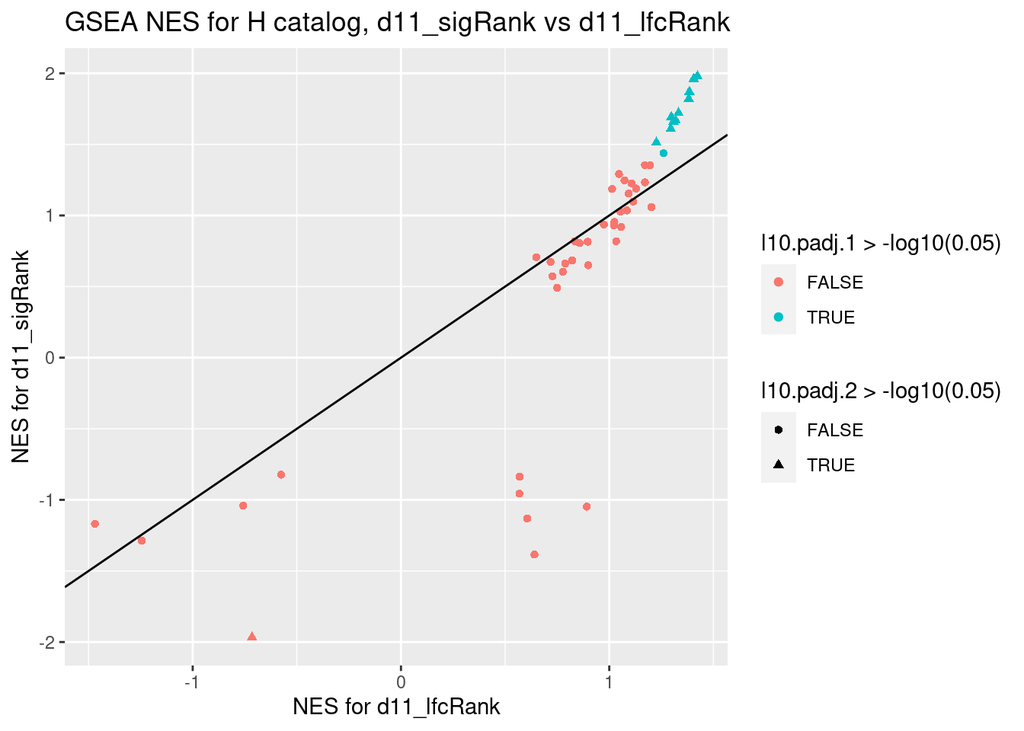

```r
p <- res.df %>%
  # skip terms where NES is NA is any data set
  dplyr::filter(!is.na(NES.1) & !is.na(NES.2)) %>%
  # plot NES of 2nd set vs NES of 1st set
  ggplot(aes(x=NES.1,
             y=NES.2,
             # color by sig in 1st set
             col=l10.padj.1>-log10(0.05),
             # shape by sig in 2nd set
             shape=l10.padj.2>-log10(0.05))
         ) +
  # show points
  geom_point() +
  # add 'identity' line
  geom_abline(intercept = 0, slope = 1) +
  # add axes labels and title
  xlab("NES for d11_lfcRank") +
  ylab("NES for d11_sigRank") +
  ggtitle("GSEA NES for H catalog, d11_sigRank vs d11_lfcRank")
p
```

List terms with NES.1 > 0 and NES.2 < 0:

```r
res.df %>%
  filter(NES.1 > 0 & NES.2 < 0) %>%
  # format score
  mutate(NES.1=formatC(NES.1, digits = 3)) %>%
  mutate(NES.2=formatC(NES.2, digits = 3)) %>%
  mutate(l10.padj.1=formatC(l10.padj.1, digits = 3)) %>%
  mutate(l10.padj.2=formatC(l10.padj.2, digits = 3)) %>%
  # format p-values
  # format p-values
  modify_at(
    c("padj.1", "padj.2"),
    format.e1
  ) %>%
  DT::datatable(options = list(dom = 't'))
```

|  | ID | NES.1 | padj.1 | NES.2 | padj.2 | l10.padj.1 | l10.padj.2 |
| --- | --- | --- | --- | --- | --- | --- | --- |
| 1 | HALLMARK_ADIPOGENESIS | 0.892 | 9.9e-01 | -1.05 | 4.1e-01 | 0.00221 | 0.39 |
| 2 | HALLMARK_BILE_ACID_METABOLISM | 0.641 | 9.9e-01 | -1.38 | 1.1e-01 | 0.00221 | 0.967 |
| 3 | HALLMARK_UV_RESPONSE_DN | 0.606 | 9.9e-01 | -1.13 | 4.3e-01 | 0.00221 | 0.366 |
| 4 | HALLMARK_SPERMATOGENESIS | 0.569 | 9.9e-01 | -0.956 | 8.6e-01 | 0.00221 | 0.0663 |
| 5 | HALLMARK_MYC_TARGETS_V1 | 0.569 | 9.9e-01 | -0.837 | 9.3e-01 | 0.00221 | 0.0295 |

Plot -log10(p.adjust):

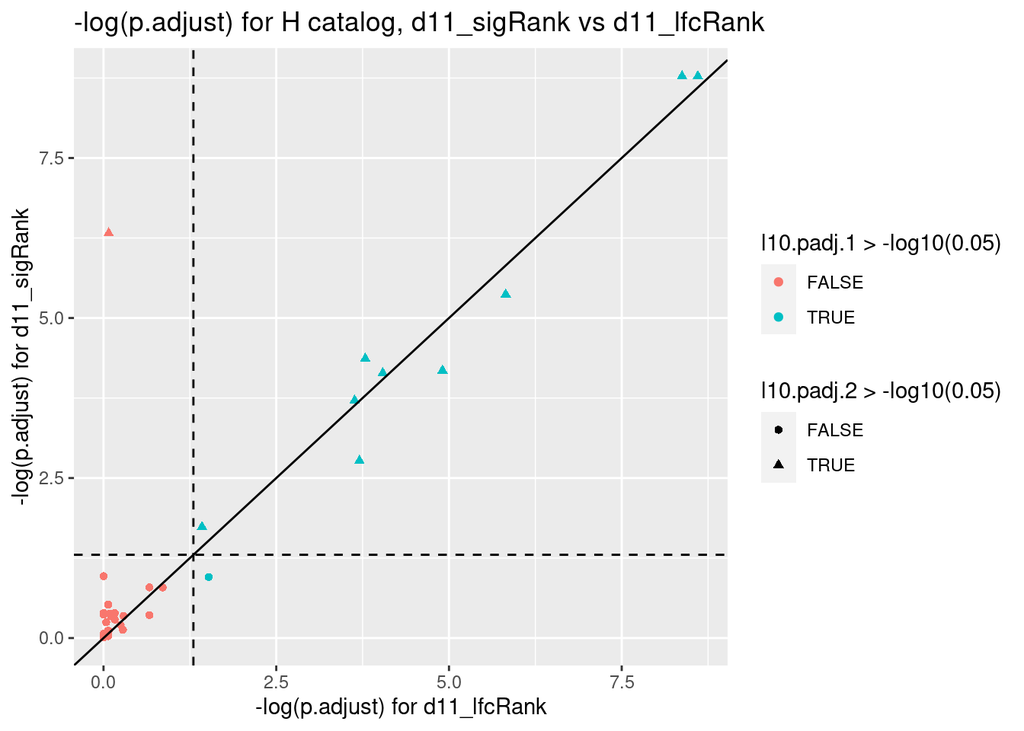

```r
p <- res.df %>%
  # skip terms where NES is NA is any data set
  dplyr::filter(!is.na(NES.1) & !is.na(NES.2)) %>%
  # plot significance strength of 2nd set vs that of 1st set
  ggplot(aes(x=l10.padj.1,
             y=l10.padj.2,
             # color by sig in 1st set
             col=l10.padj.1>-log10(0.05),
             # shape by sig in 2nd set
             shape=l10.padj.2>-log10(0.05))
         ) +
  # show points
  geom_point() +
  # add 'identity' line
  geom_abline(intercept = 0, slope = 1) +
  # add 5% significance line for set 1
  geom_vline(xintercept = -log10(0.05), linetype = 2) +
  # add 5% significance line for set 2
  geom_hline(yintercept = -log10(0.05), linetype = 2) +
  # add axes labels and title
  xlab("-log(p.adjust) for d11_lfcRank") +
  ylab("-log(p.adjust) for d11_sigRank") +
  ggtitle("-log(p.adjust) for H catalog, d11_sigRank vs d11_lfcRank")
p
```

List terms with whose significance differs between ranking schemes:

```r
diffSig <- res.df %>%
  mutate(sig005.1 = padj.1 < 0.05) %>%
  mutate(sig005.2 = padj.2 < 0.05) %>%
  mutate(sigIsDiff = (sig005.1 | sig005.2) & sig005.1 != sig005.2) %>%
  filter(sigIsDiff)
diffSig %>%
  # format score
  mutate(NES.1=formatC(NES.1, digits = 3)) %>%
  mutate(NES.2=formatC(NES.2, digits = 3)) %>%
  mutate(l10.padj.1=formatC(l10.padj.1, digits = 3)) %>%
  mutate(l10.padj.2=formatC(l10.padj.2, digits = 3)) %>%
  # format p-values
  # format p-values
  modify_at(
    c("padj.1", "padj.2"),
    format.e1
  ) %>%
  DT::datatable(options = list(dom = 't'))
```

|  | ID | NES.1 | padj.1 | NES.2 | padj.2 | l10.padj.1 | l10.padj.2 | sig005.1 | sig005.2 | sigIsDiff |
| --- | --- | --- | --- | --- | --- | --- | --- | --- | --- | --- |
| 1 | HALLMARK_COAGULATION | 1.26 | 3.0e-02 | 1.44 | 1.1e-01 | 1.52 | 0.954 | True | False | True |
| 2 | HALLMARK_OXIDATIVE_PHOSPHORYLATION | -0.715 | 8.4e-01 | -1.97 | 4.7e-07 | 0.0746 | 6.33 | False | True | True |

```r
require(ggrepel)
```

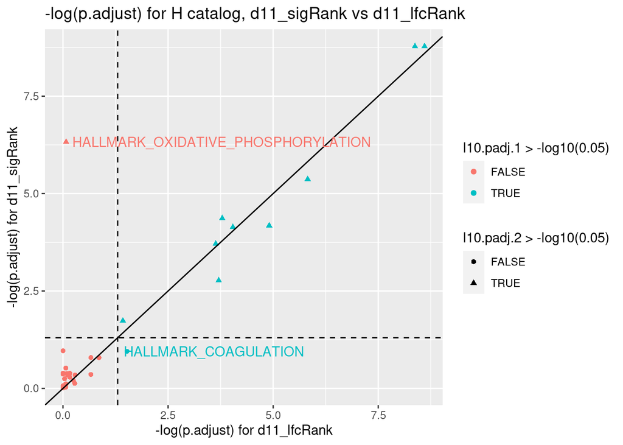

```r
p + geom_text_repel(data=diffSig,
                    aes(x=l10.padj.1,
                        y=l10.padj.2,
                        label=ID),
                    box.padding = 0.8,
                    show.legend = FALSE)
```

### Extended challenge 3 - compare outcomes for d11 and d33

Compare results obtained for d11 and d33, with genes ranked by significance and fold change direction:

First get run analysis for d11 with genes ranked by significance and logFC sign:

```r
# run analysis for d11 with genes ranked by signinficance and LFC sign
# as for d33
rankedGenes <- shrink.d11 %>%
  drop_na(Entrez, pvalue, logFC) %>%
  mutate(rank = -log10(pvalue) * sign(logFC)) %>%
  arrange(-rank) %>%
  pull(rank,Entrez)
gseaRes <- GSEA(rankedGenes,
                TERM2GENE = m_H_t2g[,1:2],
                pvalueCutoff = 1.00, # to retrieve whole output
                minGSSize = 15,
                maxGSSize = 500)
```

```
## preparing geneSet collections...
```

```
## GSEA analysis...
```

```
## leading edge analysis...
```

```
## done...
```

Combine outcomes:

```r
res.df <- gseaRes %>%
  data.frame() %>%
  # rename NES and p.adjust
  dplyr::rename(NES.1=NES, padj.1=p.adjust) %>%
  # keep "ID", "NES" and "p.adjust"
  dplyr::select(ID, NES.1, padj.1) %>%
  # merge with the d11 + significance strength
  left_join(gseaRes.e3[,c("ID", "NES", "p.adjust")]) %>%
  # rename NES and p.adjust
  dplyr::rename(NES.2=NES, padj.2=p.adjust) %>%
  # compute -log10(p.adjust)
  mutate(l10.padj.1 = -log10(padj.1),
         l10.padj.2 = -log10(padj.2))
```

Plot NES:

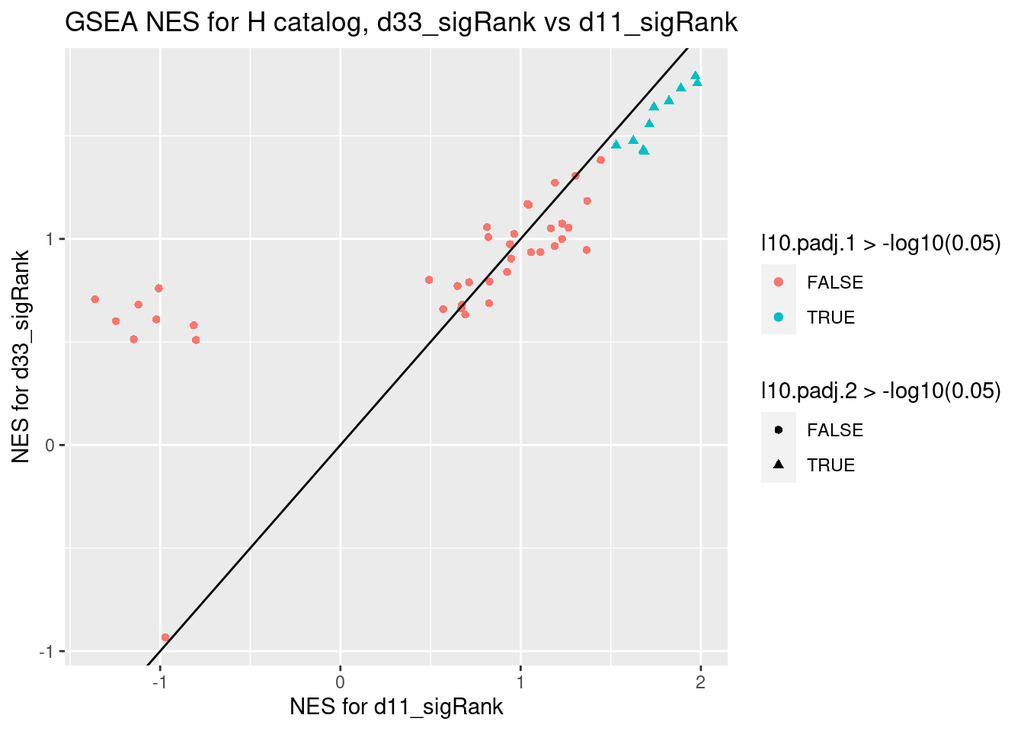

```r
res.df %>%
  dplyr::filter(!is.na(NES.1) & !is.na(NES.2)) %>%
  ggplot(aes(x=NES.1,
             y=NES.2,
             col=l10.padj.1>-log10(0.05),
             shape=l10.padj.2>-log10(0.05))
         ) +
  geom_point() +
  geom_abline(intercept = 0, slope = 1) +
  xlab("NES for d11_sigRank") +
  ylab("NES for d33_sigRank") +
  ggtitle("GSEA NES for H catalog, d33_sigRank vs d11_sigRank")
```

Plot -log10(p.adjust):

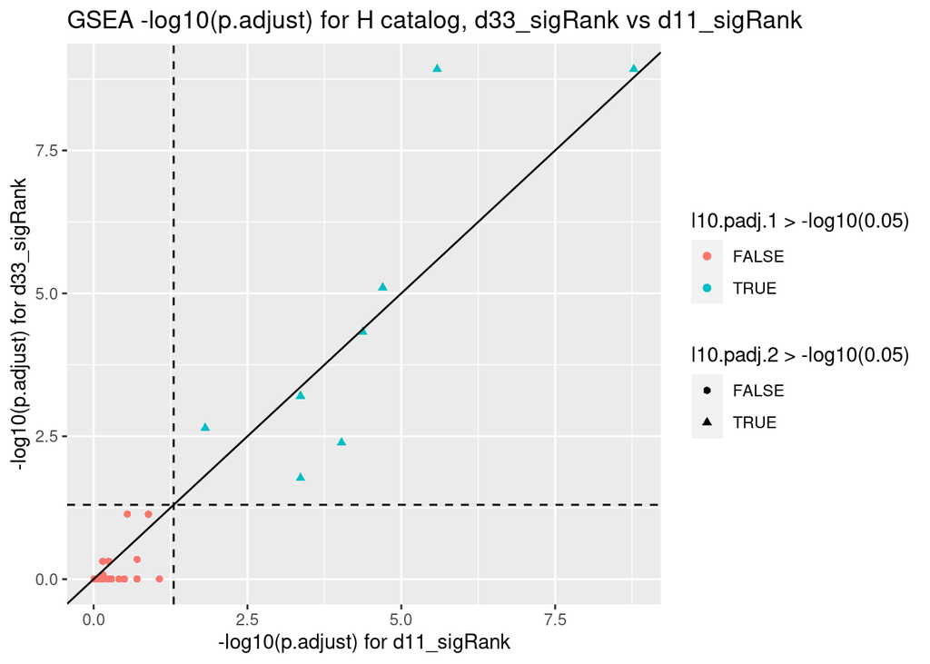

```r
res.df %>%
  dplyr::filter(!is.na(NES.1) & !is.na(NES.2)) %>%
  ggplot(aes(x=l10.padj.1,
             y=l10.padj.2,
             col=l10.padj.1>-log10(0.05),
             shape=l10.padj.2>-log10(0.05))
         ) +
  geom_point() +
  geom_abline(intercept = 0, slope = 1) +
  geom_hline(yintercept = -log10(0.05), linetype = 2) +
  geom_vline(xintercept = -log10(0.05), linetype = 2) +
  xlab("-log10(p.adjust) for d11_sigRank") +
  ylab("-log10(p.adjust) for d33_sigRank") +
  ggtitle("GSEA -log10(p.adjust) for H catalog, d33_sigRank vs d11_sigRank")
```